# Modeling Approaches

Natalia Lara

4/1/2023

# 1 Introduction

This document presents some preliminary analysis of the mobility dataset gathered in 2019 at the Military Hospital.

Optical systems have been developed from new technologies in the field of sensors and motion capture. These systems can gather high precision data and it is not user-dependent.

# 2 Data

The study was conducted on 21 patients and 21 controls with different socio-demographic characteristics. Both methods were applied at ECCI’s Biomechanics Lab. The manual method was carried out before the optimcal system. The data and results derived from the manual system were carried out by trained personnel from the Military Hospital.

The optical system had 6 Optitrack Flex 3 cameras with an acquisition rate of 100 fps. The calibration and acquisition of the kinematic data was carried out through the Motive software and, later, the data were processed through the Visual 3D software, to obtain the spinal mobility results. The experimental protocol included 29 reflective markers placed on the patient or individual’s body.

## 2.1 Data

The following table presents the variables that were measurements for the controls and patients with gait disorder:

```r
patients <- read_csv('Data/patients.csv')
patients$NUMERO <- as_factor(patients$NUMERO)
patients$ID <- as_factor(patients$ID)
patients$BIOLOGICO <- as_factor(patients$BIOLOGICO)
patients$TIPO <- as_factor(patients$TIPO)
patients$CONTROLADO <- patients$CONTROLADO

# mass in kg

#sep_bp_patients <- str_split(patients$PRESION_ARTERIAL, '/')

#SYSTOLIC = DIASTOLIC = 0

#for(i in (1:nrow(patients))){
#  SYSTOLIC[i] = as.numeric(sep_bp_patients[[i]][1])
#  DIASTOLIC[i] = as.numeric(sep_bp_patients[[i]][2])
#}

#patients$SYSTOLIC <- SYSTOLIC
#patients$DIASTOLIC <- DIASTOLIC

#-------------------------------------------------------------------------------

controls <- read_csv('Data/controls.csv')
controls$NUMERO <- as_factor(controls$NUMERO)
controls$ID <- as_factor(controls$ID)
controls$BIOLOGICO <- as_factor(controls$BIOLOGICO)
controls$TIPO <- as_factor(controls$TIPO)
controls$CONTROLADO <- 'SI'

datos <- rbind(patients, controls)

datos <- datos %>%
  select(PESO_kg, ROTA_CERV_LAB_IZQUIERDA, ROTA_CERV_LAB_DERECHA,
         FLEX_FRONT_CERV_LAB_GRAD_FLEXION, FLEX_FRONT_CERV_LAB_GRAD_EXTESION,
         FLEX_LAT_CERV_LAB_GRAD_DERECHA, FLEX_LAT_CERV_LAB_GRAD_IZQUIERDA,
         SHOBERT_MODIFICADO_CM_LABORATORIO, FLEX_LUMBAR_LAT_LAB_CM_DERECHA,
         FLEX_LUMBAR_LAT_LAB_CM_IZQUIERDA, DISTANCIA_INTERMALEOLAR_LAB_CM,
         CONTROLADO)

write_csv(datos, 'Data/datos.csv')
rm(patients)
rm(controls)

names(datos)[2] <- 'ROTA_CERV_IZQ'                           # in degrees
names(datos)[3] <- 'ROTA_CERV_DER'                           # in degrees
names(datos)[4] <- 'FLEX_FRONT_CERV_FLEXION'                 # in degrees
names(datos)[5] <- 'FLEX_FRONT_CERV_EXTENSION'               # in degrees
names(datos)[6] <- 'FLEX_LAT_CERV_DERECHA'                   # in degrees
names(datos)[7] <- 'FLEX_LAT_CERV_IZQUIERDA'                 # in degrees
names(datos)[8] <- 'SCHOBERT_MOD'                             # in cm
names(datos)[9] <- 'FLEX_LUMBAR_LAT_DERECHA'                 # in cm
names(datos)[10] <- 'FLEX_LUMBAR_LAT_IZQUIERDA'              # in cm
names(datos)[11] <- 'DISTANCIA_INTERMALEOLAR'                # in cm

datos$CONTROLADO <- as_factor(datos$CONTROLADO)

datos <- datos[complete.cases(datos),]

datos %>%
  kbl(booktabs = T) %>%
  kable_material(c('hover', 'striped'), full_width = F) %>%
  scroll_box(width = "100%", height = "350px")
```

| PESO_kg | ROTA_CERV_IZQ | ROTA_CERV_DER | FLEX_FRONT_CERV_FLEXION | FLEX_FRONT_CERV_EXTENSION | FLEX_LAT_CERV_DERECHA | FLEX_LAT_CERV_IZQUIERDA | SCHOBERT_MOD | FLEX_LUMBAR_LAT_DERECHA | FLEX_LUMBAR_LAT_IZQUIERDA | DISTANCIA_INTERMALEOLAR | CONTROLADO |
| --- | --- | --- | --- | --- | --- | --- | --- | --- | --- | --- | --- |
| 78.5 | 70.60 | 49.8 | 40.0 | 29.50 | 38.0 | 37.00 | 16.0 | 16.50 | 16.60 | 28.3 | SI |
| 98.4 | 37.60 | 39.6 | 13.7 | 19.60 | 25.3 | 14.60 | 13.0 | 8.00 | 8.50 | 21.0 | NO |
| 116.0 | 49.80 | 46.4 | 37.0 | 20.90 | 30.6 | 30.40 | 20.0 | 20.00 | 19.00 | 33.0 | SI |
| 87.5 | 58.30 | 44.3 | 26.7 | 18.40 | 22.0 | 19.60 | 18.0 | 8.30 | 9.30 | 20.0 | NO |
| 69.4 | 66.33 | 43.3 | 35.1 | 19.20 | 28.6 | 35.00 | 22.0 | 17.00 | 20.70 | 38.0 | NO |
| 99.0 | 48.60 | 44.0 | 25.1 | 21.10 | 17.3 | 18.60 | 15.0 | 7.50 | 6.60 | 37.1 | SI |
| 62.0 | 51.60 | 48.3 | 28.4 | 17.40 | 24.1 | 18.55 | 21.0 | 9.90 | 9.50 | 29.0 | SI |
| 68.3 | 65.20 | 62.4 | 42.4 | 40.30 | 39.1 | 35.60 | 19.4 | 21.00 | 19.00 | 28.0 | SI |
| 64.8 | 53.80 | 47.0 | 22.9 | 17.90 | 16.9 | 20.70 | 19.0 | 13.90 | 9.50 | 23.0 | NO |
| 76.0 | 63.10 | 58.4 | 44.2 | 31.40 | 45.8 | 41.80 | 20.4 | 15.00 | 15.00 | 31.0 | SI |
| 86.6 | 48.40 | 56.0 | 16.8 | 11.33 | 33.9 | 31.40 | 18.7 | 19.00 | 19.00 | 20.0 | NO |
| 66.5 | 37.30 | 42.7 | 24.2 | 24.20 | 18.8 | 17.70 | 20.7 | 20.00 | 20.00 | 25.0 | NO |
| 83.5 | 48.20 | 51.2 | 26.6 | 24.40 | 31.6 | 31.30 | 18.0 | 11.20 | 12.40 | 40.7 | NO |
| 52.8 | 43.20 | 46.5 | 37.1 | 18.00 | 15.3 | 15.00 | 20.0 | 17.70 | 18.00 | 20.0 | SI |
| 64.0 | 19.80 | 21.0 | 29.3 | 32.60 | 35.2 | 34.30 | 20.7 | 15.00 | 14.00 | 32.0 | NO |
| 57.9 | 60.00 | 63.0 | 39.7 | 39.60 | 30.6 | 27.00 | 18.0 | 13.20 | 12.30 | 27.3 | NO |
| 70.0 | 45.40 | 51.0 | 33.7 | 30.60 | 21.6 | 21.40 | 22.8 | 6.40 | 6.40 | 33.0 | SI |
| 59.7 | 24.10 | 31.5 | 19.2 | 16.20 | 13.8 | 17.80 | 15.7 | 7.90 | 8.90 | 22.0 | NO |
| 67.0 | 49.90 | 49.7 | 12.7 | 12.30 | 30.7 | 27.10 | 15.8 | 9.20 | 8.80 | 36.0 | NO |
| 86.5 | 49.30 | 45.2 | 33.4 | 26.70 | 20.7 | 19.50 | 15.7 | 9.40 | 9.70 | 32.0 | SI |
| 85.9 | 51.60 | 41.3 | 35.4 | 24.20 | 25.3 | 26.60 | 15.7 | 11.40 | 12.20 | 44.0 | SI |
| 78.8 | 52.20 | 57.0 | 37.9 | 25.20 | 38.2 | 40.70 | 17.0 | 15.50 | 15.30 | 34.0 | SI |
| 75.0 | 51.50 | 59.8 | 37.0 | 38.70 | 38.6 | 29.40 | 23.8 | 15.10 | 17.00 | 30.0 | SI |
| 72.0 | 56.00 | 55.6 | 52.8 | 30.20 | 38.3 | 35.10 | 18.7 | 18.00 | 18.00 | 33.0 | SI |
| 100.0 | 43.20 | 40.0 | 20.5 | 20.80 | 17.2 | 18.40 | 17.7 | 18.00 | 16.40 | 26.0 | SI |
| 87.0 | 60.00 | 48.2 | 32.2 | 26.10 | 29.0 | 30.80 | 20.7 | 22.50 | 22.00 | 46.0 | SI |
| 83.0 | 56.70 | 55.0 | 45.6 | 34.40 | 41.7 | 41.90 | 19.8 | 19.50 | 19.50 | 34.0 | SI |
| 74.0 | 55.30 | 62.8 | 39.6 | 32.00 | 17.6 | 21.30 | 24.8 | 17.00 | 18.00 | 26.0 | SI |
| 76.0 | 76.00 | 60.9 | 50.9 | 41.00 | 24.5 | 27.50 | 21.7 | 17.00 | 19.00 | 37.0 | SI |
| 79.5 | 58.30 | 62.3 | 36.8 | 31.90 | 35.9 | 41.90 | 22.4 | 20.00 | 19.00 | 26.0 | SI |
| 91.0 | 53.40 | 49.3 | 34.0 | 30.20 | 33.4 | 28.00 | 24.3 | 19.00 | 16.00 | 41.0 | SI |
| 58.0 | 52.50 | 53.5 | 37.4 | 27.30 | 35.4 | 27.80 | 21.0 | 15.16 | 15.47 | 27.0 | SI |
| 63.1 | 70.80 | 80.3 | 46.8 | 26.20 | 33.7 | 38.50 | 22.0 | 14.70 | 17.80 | 40.0 | SI |
| 63.0 | 60.80 | 50.4 | 46.8 | 44.70 | 34.9 | 38.90 | 21.0 | 16.90 | 17.30 | 31.0 | SI |
| 93.0 | 60.30 | 55.5 | 36.8 | 46.00 | 41.2 | 34.00 | 26.0 | 15.70 | 16.30 | 36.0 | SI |
| 74.0 | 61.40 | 60.3 | 35.0 | 26.30 | 42.0 | 36.60 | 25.0 | 18.70 | 21.60 | 42.0 | SI |
| 82.6 | 43.10 | 46.4 | 26.6 | 31.80 | 26.2 | 27.40 | 23.0 | 15.80 | 18.00 | 29.0 | SI |
| 40.0 | 54.80 | 56.5 | 31.1 | 26.70 | 33.8 | 33.80 | 20.0 | 13.90 | 15.60 | 40.0 | SI |
| 60.3 | 57.40 | 62.5 | 47.8 | 28.00 | 38.8 | 36.90 | 22.0 | 19.60 | 24.60 | 35.0 | SI |
| 61.0 | 60.60 | 65.4 | 25.8 | 18.60 | 23.3 | 23.10 | 18.7 | 20.00 | 18.00 | 33.0 | SI |

A correlation analysis provides an idea about the symmetric (assymmetric) characteristics of the sampling units. Note that there are variables that were measured on both sides, and thus, a healthy and symmetric patients tend to be highly symmetric in these markers:

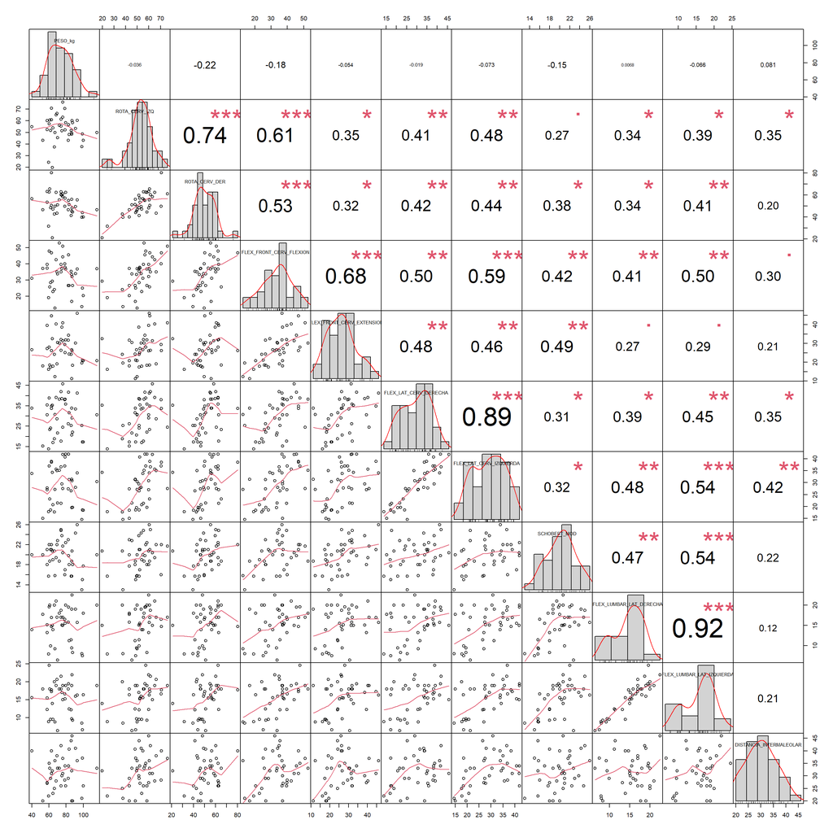

```r
chart.Correlation(datos[ , -(12)], histogram = T)
```

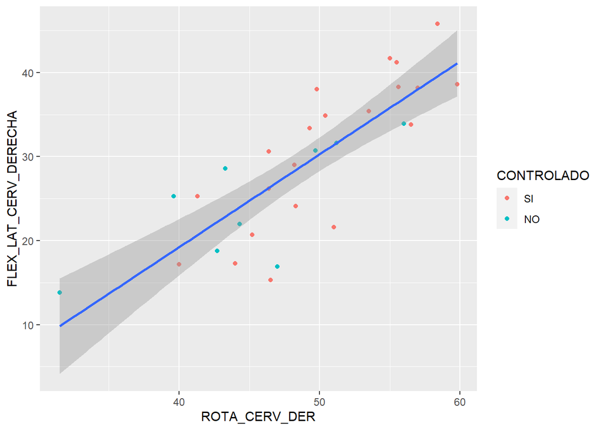

```r
datos %>%
  filter(ROTA_CERV_DER > 25, ROTA_CERV_DER < 60) %>%
  ggplot(aes(x = ROTA_CERV_DER, y = FLEX_LAT_CERV_DERECHA)) +
  geom_point(aes(colour = CONTROLADO)) +
  geom_smooth(method = 'lm')
```

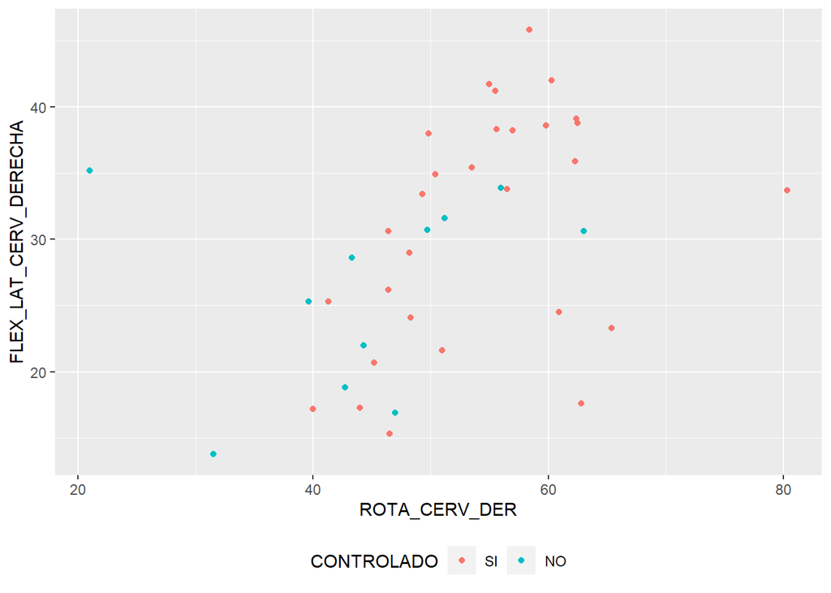

```r
datos %>%
  ggplot(aes(x = ROTA_CERV_DER, y = FLEX_LAT_CERV_DERECHA)) +
  geom_point(aes(colour = CONTROLADO)) +
  theme(legend.position = 'bottom')
```

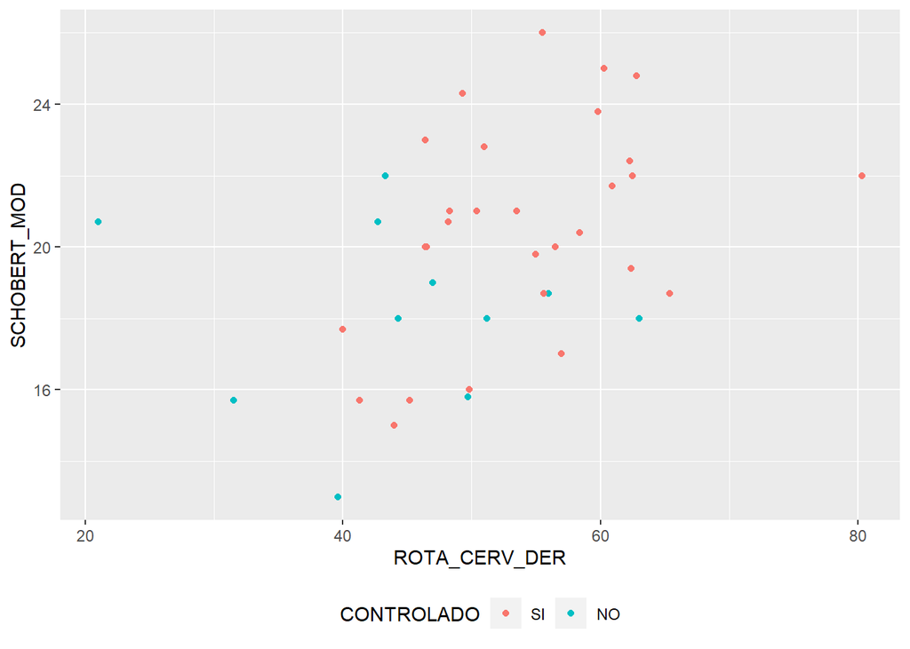

```r
datos %>%
  ggplot(aes(x = ROTA_CERV_DER, y = SCHOBERT_MOD)) +
  geom_point(aes(colour = CONTROLADO)) +
  theme(legend.position = 'bottom')
```

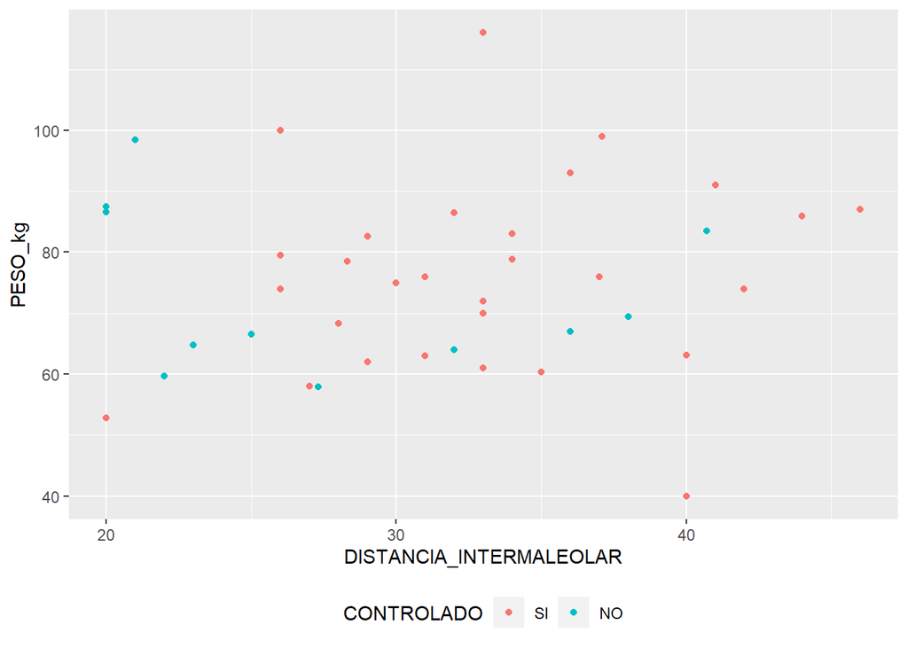

```r
datos %>%
  ggplot(aes(x = DISTANCIA_INTERMALEOLAR, y = PESO_kg)) +
  geom_point(aes(colour = CONTROLADO)) +
  theme(legend.position = 'bottom')
```

```r
datos %>%
  filter(ROTA_CERV_DER > 25, ROTA_CERV_DER < 60) %>%
  mutate(correlation = cor(ROTA_CERV_DER, FLEX_LAT_CERV_DERECHA))
```

```
## # A tibble: 30 x 13
##    PESO_kg ROTA_CERV_IZQ ROTA_CERV_DER FLEX_FRONT_CERV_FLEXION
##      <dbl>         <dbl>         <dbl>                   <dbl>
##  1    78.5          70.6          49.8                    40
##  2    98.4          37.6          39.6                    13.7
##  3   116            49.8          46.4                    37
##  4    87.5          58.3          44.3                    26.7
##  5    69.4          66.3          43.3                    35.1
##  6    99            48.6          44                      25.1
##  7    62            51.6          48.3                    28.4
##  8    64.8          53.8          47                      22.9
##  9    76            63.1          58.4                    44.2
## 10    86.6          48.4          56                      16.8
## # i 20 more rows
## # i 9 more variables: FLEX_FRONT_CERV_EXTENSION <dbl>,
## #   FLEX_LAT_CERV_DERECHA <dbl>, FLEX_LAT_CERV_IZQUIERDA <dbl>,
## #   SCHOBERT_MOD <dbl>, FLEX_LUMBAR_LAT_DERECHA <dbl>,
## #   FLEX_LUMBAR_LAT_IZQUIERDA <dbl>, DISTANCIA_INTERMALEOLAR <dbl>,
## #   CONTROLADO <fct>, correlation <dbl>
```

```r
cor(datos$ROTA_CERV_DER, datos$FLEX_LAT_CERV_DERECHA)
```

```
## [1] 0.4225125
```

Exploration

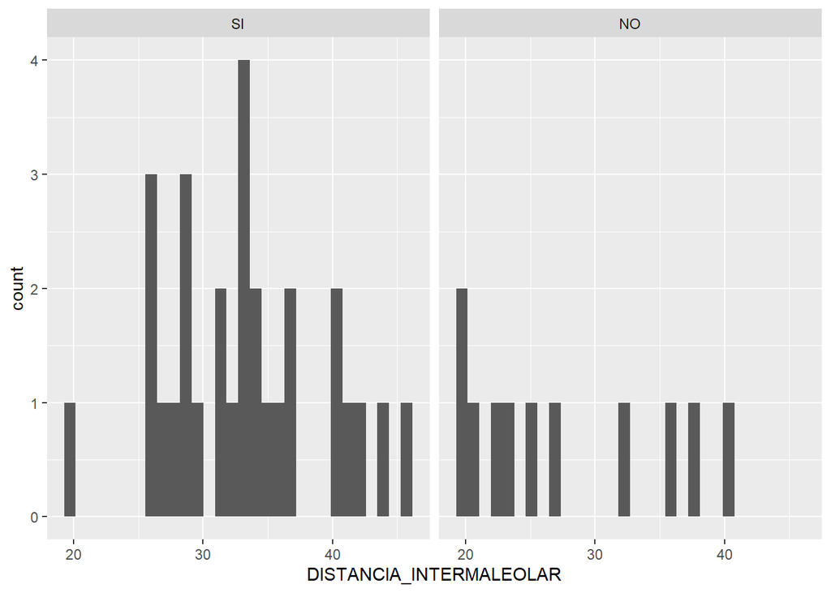

```r
datos %>%
  ggplot(aes(x = DISTANCIA_INTERMALEOLAR)) +
  geom_histogram() +
  facet_wrap(~CONTROLADO)
```

```r
DISTANCIA_INTERMALEOLAR_SI <- datos %>%
  filter(CONTROLADO == 'SI') %>%
  pull(DISTANCIA_INTERMALEOLAR)

DISTANCIA_INTERMALEOLAR_NO <- datos %>%
  filter(CONTROLADO == 'NO') %>%
  pull(DISTANCIA_INTERMALEOLAR)

shap_wilk_dist_intermaleolar_si <- shapiro.test(DISTANCIA_INTERMALEOLAR_SI)
shap_wilk_dist_intermaleolar_no <- shapiro.test(DISTANCIA_INTERMALEOLAR_NO)

shap_wilk_dist_intermaleolar_si[['p.value']]
```

```
## [1] 0.8331072
```

```r
shap_wilk_dist_intermaleolar_no[['p.value']]
```

```
## [1] 0.08999334
```

```r
datos %>%
  group_by(CONTROLADO) %>%
  summarize(mean = mean(DISTANCIA_INTERMALEOLAR), sd = sd(DISTANCIA_INTERMALEOLAR), n = n())
```

```
## # A tibble: 2 x 4
##   CONTROLADO  mean    sd     n
##   <fct>      <dbl> <dbl> <int>
## 1 SI          33.2  6.06    29
## 2 NO          27.7  7.67    11
```

```r
bootstrap <- function(vect){
    n <- length(vect)
    bootstrap_indices <- sample(x = 1:n, size = n, replace = TRUE)
    vect[bootstrap_indices]
}
```

```r
bootstrapped_sample_means <- replicate(n = 1E3, expr = mean(bootstrap(datos$PESO_kg)))

bootstrap_sd <- sd(bootstrapped_sample_means)
bootstrap_sd
```

```
## [1] 2.351218
```

# 3 Models

## 3.1 Logistic Regression (Naive approach)

Full model:

```r
full_naive_model_log_reg <- glm(CONTROLADO ~ .,
                                data = datos, family = "binomial")

summary(full_naive_model_log_reg)
```

```
##
## Call:
## glm(formula = CONTROLADO ~ ., family = "binomial", data = datos)
##
## Deviance Residuals:
##      Min        1Q    Median        3Q       Max
## -1.82037  -0.32111  -0.05356   0.03617   1.83965
##
## Coefficients:
##                           Estimate Std. Error z value Pr(>|z|)
## (Intercept)               33.01390   17.83247   1.851   0.0641 .
## PESO_kg                   -0.10899    0.06129  -1.778   0.0753 .
## ROTA_CERV_IZQ              0.06648    0.10871   0.612   0.5409
## ROTA_CERV_DER             -0.11397    0.10593  -1.076   0.2819
## FLEX_FRONT_CERV_FLEXION   -0.38203    0.18202  -2.099   0.0358 *
## FLEX_FRONT_CERV_EXTENSION  0.12245    0.13653   0.897   0.3698
## FLEX_LAT_CERV_DERECHA     -0.17622    0.28606  -0.616   0.5379
## FLEX_LAT_CERV_IZQUIERDA    0.31123    0.31251   0.996   0.3193
## SCHOBERT_MOD              -0.44795    0.43078  -1.040   0.2984
## FLEX_LUMBAR_LAT_DERECHA   -0.74777    0.63842  -1.171   0.2415
## FLEX_LUMBAR_LAT_IZQUIERDA  0.56271    0.55441   1.015   0.3101
## DISTANCIA_INTERMALEOLAR   -0.24474    0.16942  -1.445   0.1486
## ---
## Signif. codes:  0 '***' 0.001 '**' 0.01 '*' 0.05 '.' 0.1 ' ' 1
##
## (Dispersion parameter for binomial family taken to be 1)
##
##     Null deviance: 47.054  on 39  degrees of freedom
## Residual deviance: 19.091  on 28  degrees of freedom
## AIC: 43.091
##
## Number of Fisher Scoring iterations: 7
```

Confusion Matrix:

```r
full_naive_model_log_reg_pred <- predict(full_naive_model_log_reg, datos)
full_naive_model_log_reg_pred <- as_factor(if_else(full_naive_model_log_reg_pred < 0.5, 'SI', 'NO'))

confusionMatrix(full_naive_model_log_reg_pred, datos$CONTROLADO)
```

```
## Confusion Matrix and Statistics
##
##           Reference
## Prediction SI NO
##         SI 28  4
##         NO  1  7
##
##                Accuracy : 0.875
##                  95% CI : (0.732, 0.9581)
##     No Information Rate : 0.725
##     P-Value [Acc > NIR] : 0.02002
##
##                   Kappa : 0.6575
##
##  Mcnemar's Test P-Value : 0.37109
##
##             Sensitivity : 0.9655
##             Specificity : 0.6364
##          Pos Pred Value : 0.8750
##          Neg Pred Value : 0.8750
##              Prevalence : 0.7250
##          Detection Rate : 0.7000
##    Detection Prevalence : 0.8000
##       Balanced Accuracy : 0.8009
##
##        'Positive' Class : SI
##
```

ROC:

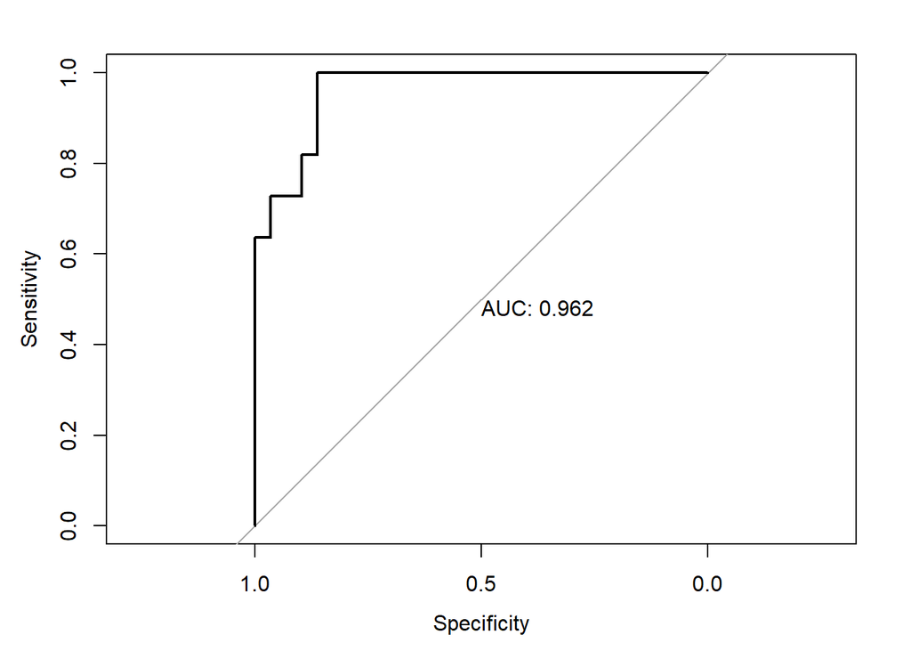

```r
get_roc_curve(full_naive_model_log_reg)
```

### 3.1.1 ROC curve and Sub-Models

Cutoffs: 0.2, 0.3, 0.5, 0.7, 0.90.

Function to get a roc curve (`get_roc_curve()`):

```r
get_roc_curve <- function(mod){

  test_pred_20 <- predict(mod,
                          datos, type = 'response')

  test_pred_20 <- as_factor(if_else(test_pred_20 < 0.2, 'SI', 'NO'))


  test_pred_30 <- predict(mod,
                          datos, type = 'response')

  test_pred_30 <- as_factor(if_else(test_pred_30 < 0.3, 'SI', 'NO'))

  #test_pred_40 <- predict(mod,
  #                        patients, type = 'response')
  #test_pred_40 <- as_factor(if_else(test_pred_40 < 0.4, 'SI', 'NO'))


  test_pred_50 <- predict(mod,
                          datos, type = 'response')

  test_pred_50 <- as_factor(if_else(test_pred_50 < 0.5, 'SI', 'NO'))

  #test_pred_60 <- predict(mod,
  #                        patients, type = 'response')
  #test_pred_60 <- as_factor(if_else(test_pred_60 < 0.6, 'SI', 'NO'))

  test_pred_70 <- predict(mod,
                          datos, type = 'response')

  test_pred_70 <- as_factor(if_else(test_pred_70 < 0.7, 'SI', 'NO'))

  #test_pred_80 <- predict(mod,
  #                        patients, type = 'response')
  #test_pred_80 <- as_factor(if_else(test_pred_80 < 0.8, 'SI', 'NO'))

  test_pred_90 <- predict(mod,
                          datos, type = 'response')

  test_pred_90 <- as_factor(if_else(test_pred_90 < 0.9, 'SI', 'NO'))

  #test_pred_95 <- predict(mod,
  #                        patients, type = 'response')

  #test_pred_95 <- as_factor(if_else(test_pred_95 < 0.95, 'SI', 'NO'))

  # Confusion Matrix:

  test_con_mat_20 = confusionMatrix(test_pred_20,
                                    datos$CONTROLADO)

  test_con_mat_30 = confusionMatrix(test_pred_30,
                                    datos$CONTROLADO)
  #test_con_mat_40 = confusionMatrix(test_pred_40,
  #                                  patients$CONTROLADO)
  test_con_mat_50 = confusionMatrix(test_pred_50,
                                    datos$CONTROLADO)
  #test_con_mat_60 = confusionMatrix(test_pred_60,
  #                                  patients$CONTROLADO)
  test_con_mat_70 = confusionMatrix(test_pred_70,
                                    datos$CONTROLADO)
  #test_con_mat_80 = confusionMatrix(test_pred_80,
  #                                  patients$CONTROLADO)
  test_con_mat_90 = confusionMatrix(test_pred_90,
                                    datos$CONTROLADO)
  #test_con_mat_95 = confusionMatrix(test_pred_95,
  #                                  patients$CONTROLADO)

  # Metrics:

  metrics = rbind(

  c(test_con_mat_20$overall["Accuracy"],
    test_con_mat_20$byClass["Sensitivity"],
    test_con_mat_20$byClass["Specificity"]),

  c(test_con_mat_30$overall["Accuracy"],
    test_con_mat_30$byClass["Sensitivity"],
    test_con_mat_30$byClass["Specificity"]),

  #c(test_con_mat_40$overall["Accuracy"],
  #  test_con_mat_40$byClass["Sensitivity"],
  #  test_con_mat_40$byClass["Specificity"]),

  c(test_con_mat_50$overall["Accuracy"],
    test_con_mat_50$byClass["Sensitivity"],
    test_con_mat_50$byClass["Specificity"]),

  #c(test_con_mat_60$overall["Accuracy"],
  #  test_con_mat_60$byClass["Sensitivity"],
  #  test_con_mat_60$byClass["Specificity"]),

  c(test_con_mat_70$overall["Accuracy"],
    test_con_mat_70$byClass["Sensitivity"],
    test_con_mat_70$byClass["Specificity"]),

  #c(test_con_mat_80$overall["Accuracy"],
  #  test_con_mat_80$byClass["Sensitivity"],
  #  test_con_mat_80$byClass["Specificity"]),

  c(test_con_mat_90$overall["Accuracy"],
    test_con_mat_90$byClass["Sensitivity"],
    test_con_mat_90$byClass["Specificity"])#,

  #c(test_con_mat_95$overall["Accuracy"],
  #  test_con_mat_95$byClass["Sensitivity"],
  #  test_con_mat_95$byClass["Specificity"]),
  )

  #rownames(metrics) = c('c = 0.20', 'c = 0.30', 'c = 0.40',
  #                      'c = 0.50', 'c = 0.60', 'c = 0.70',
  #                      'c = 0.80', 'c = 0.90', 'c = 0.95')

  rownames(metrics) = c('c = 0.20', 'c = 0.30', 'c = 0.50',
                        'c = 0.70', 'c = 0.90')

  # ROC curve:

  test_prob = predict(mod,
                      newdata = datos,
                      type = "response")

  test_roc = roc(datos$CONTROLADO ~ test_prob, plot = TRUE, print.auc = TRUE)

}
```

#### 3.1.1.1 Cervical Rotation (Right-side)

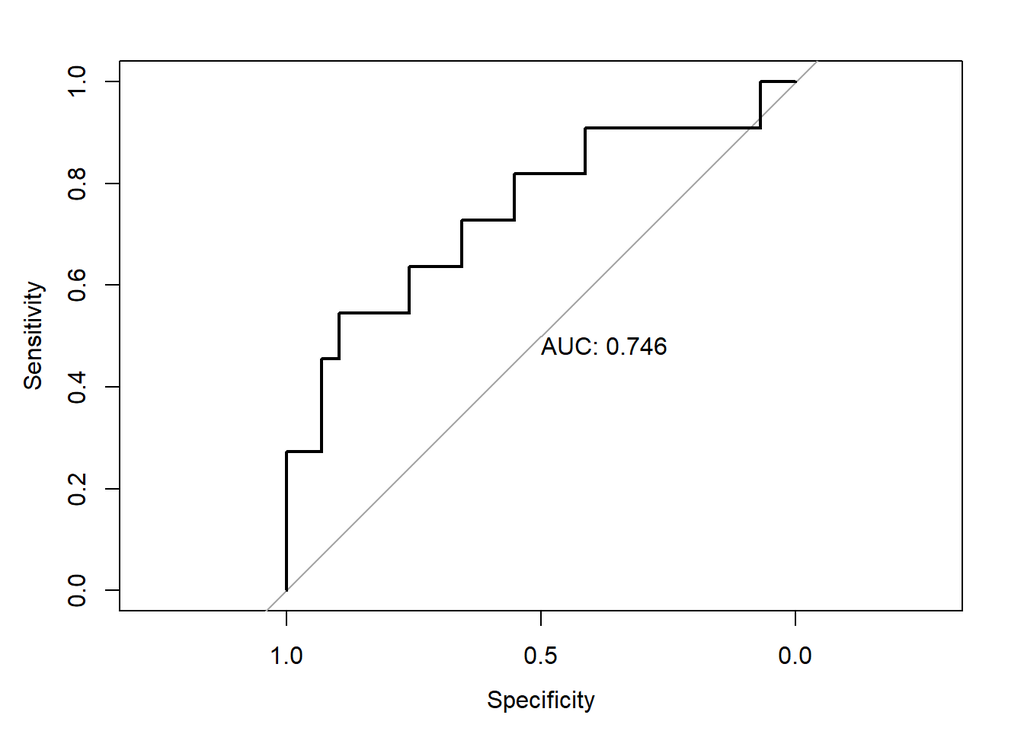

```r
ROTA_CERV_DER_log_reg <- glm(CONTROLADO ~ ROTA_CERV_DER,
                             data = datos, family = "binomial")

get_roc_curve(ROTA_CERV_DER_log_reg)
```

Summary:

```r
summary(ROTA_CERV_DER_log_reg)
```

```
##
## Call:
## glm(formula = CONTROLADO ~ ROTA_CERV_DER, family = "binomial",
##     data = datos)
##
## Deviance Residuals:
##     Min       1Q   Median       3Q      Max
## -1.2670  -0.7996  -0.4742   0.4706   2.3147
##
## Coefficients:
##               Estimate Std. Error z value Pr(>|z|)
## (Intercept)    5.10538    2.56253   1.992   0.0463 *
## ROTA_CERV_DER -0.12243    0.05224  -2.343   0.0191 *
## ---
## Signif. codes:  0 '***' 0.001 '**' 0.01 '*' 0.05 '.' 0.1 ' ' 1
##
## (Dispersion parameter for binomial family taken to be 1)
##
##     Null deviance: 47.054  on 39  degrees of freedom
## Residual deviance: 38.785  on 38  degrees of freedom
## AIC: 42.785
##
## Number of Fisher Scoring iterations: 5
```

Graph:

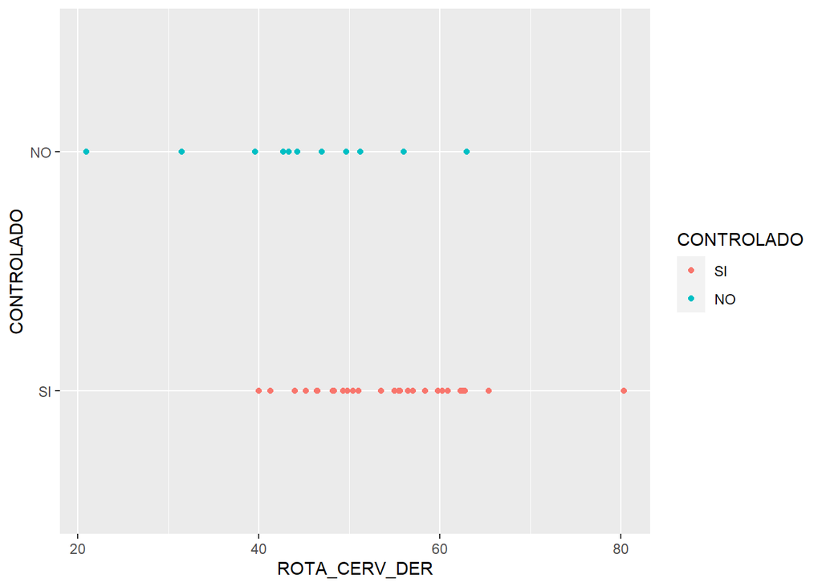

```r
datos %>%
  ggplot(aes(x = ROTA_CERV_DER, y = CONTROLADO)) +
  geom_point(aes(colour = CONTROLADO))
```

Predictions:

```r
ROTA_CERV_DER_log_reg_pred <- predict(ROTA_CERV_DER_log_reg, datos)
ROTA_CERV_DER_log_reg_pred <- as_factor(if_else(ROTA_CERV_DER_log_reg_pred < 0.5, 'SI', 'NO'))

confusionMatrix(ROTA_CERV_DER_log_reg_pred, datos$CONTROLADO)
```

```
## Confusion Matrix and Statistics
##
##           Reference
## Prediction SI NO
##         SI 29  9
##         NO  0  2
##
##                Accuracy : 0.775
##                  95% CI : (0.6155, 0.8916)
##     No Information Rate : 0.725
##     P-Value [Acc > NIR] : 0.304784
##
##                   Kappa : 0.2437
##
##  Mcnemar's Test P-Value : 0.007661
##
##             Sensitivity : 1.0000
##             Specificity : 0.1818
##          Pos Pred Value : 0.7632
##          Neg Pred Value : 1.0000
##              Prevalence : 0.7250
##          Detection Rate : 0.7250
##    Detection Prevalence : 0.9500
##       Balanced Accuracy : 0.5909
##
##        'Positive' Class : SI
##
```

#### 3.1.1.2 Cervical Rotation (Left-side)

Then,

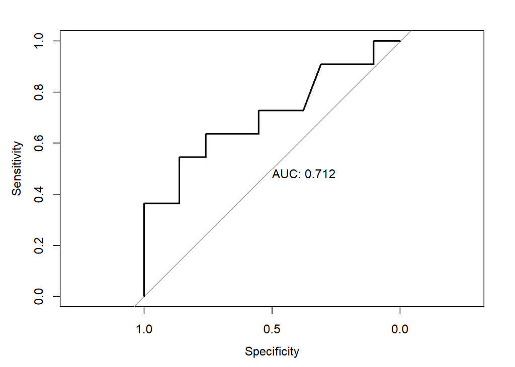

```r
ROTA_CERV_IZQ_log_reg <- glm(CONTROLADO ~ ROTA_CERV_IZQ,
                             data = datos, family = "binomial")

get_roc_curve(ROTA_CERV_IZQ_log_reg)
```

#### 3.1.1.3 Modified Schobert

Then,

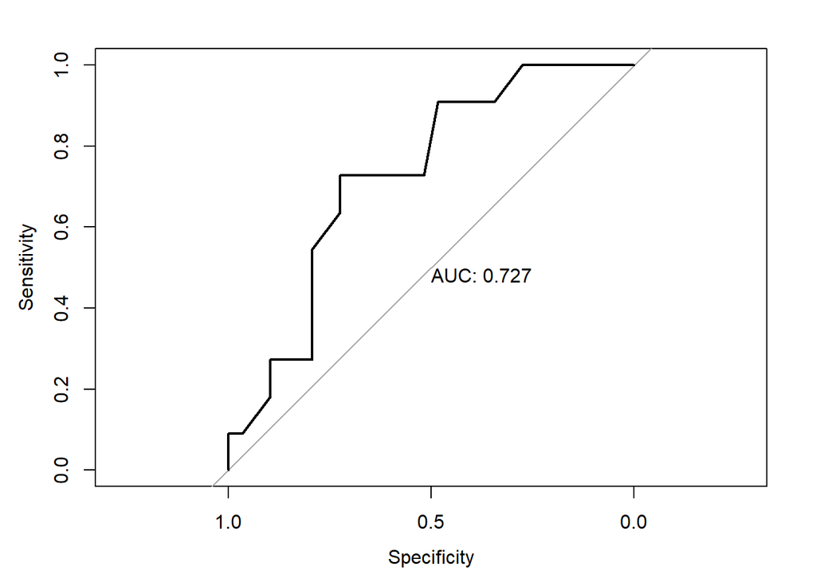

```r
SCHOBERT_MOD_log_reg <- glm(CONTROLADO ~ SCHOBERT_MOD,
                            data = datos, family = "binomial")

get_roc_curve(SCHOBERT_MOD_log_reg)
```

Predictions:

```r
SCHOBERT_MOD_log_reg_pred <- predict(SCHOBERT_MOD_log_reg, datos)
SCHOBERT_MOD_log_reg_pred <- as_factor(if_else(SCHOBERT_MOD_log_reg_pred < 0.5, 'SI', 'NO'))

confusionMatrix(SCHOBERT_MOD_log_reg_pred, datos$CONTROLADO)
```

```
## Confusion Matrix and Statistics
##
##           Reference
## Prediction SI NO
##         SI 29 10
##         NO  0  1
##
##                Accuracy : 0.75
##                  95% CI : (0.588, 0.8731)
##     No Information Rate : 0.725
##     P-Value [Acc > NIR] : 0.440206
##
##                   Kappa : 0.1266
##
##  Mcnemar's Test P-Value : 0.004427
##
##             Sensitivity : 1.00000
##             Specificity : 0.09091
##          Pos Pred Value : 0.74359
##          Neg Pred Value : 1.00000
##              Prevalence : 0.72500
##          Detection Rate : 0.72500
##    Detection Prevalence : 0.97500
##       Balanced Accuracy : 0.54545
##
##        'Positive' Class : SI
##
```

#### 3.1.1.4 Intermaleolar Distance

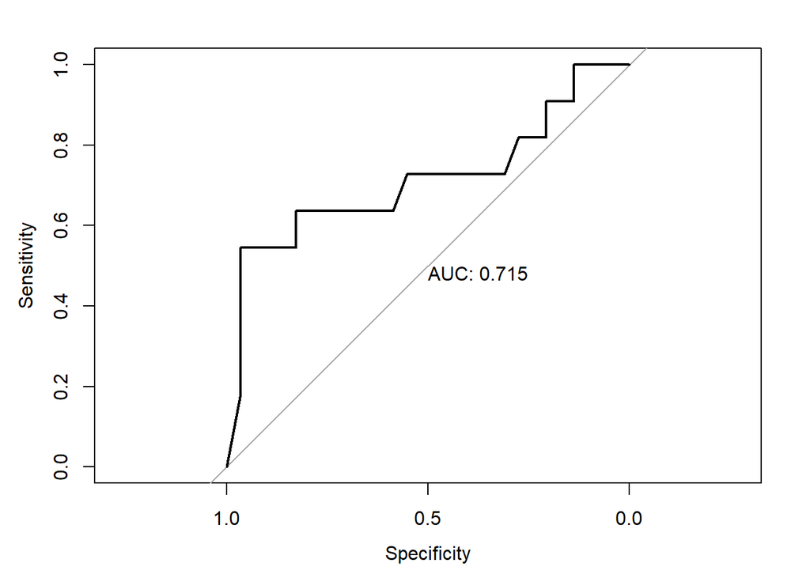

```r
DISTANCIA_INTERMALEOLAR_log_reg <- glm(CONTROLADO ~ DISTANCIA_INTERMALEOLAR,
                                       data = datos, family = "binomial")

get_roc_curve(DISTANCIA_INTERMALEOLAR_log_reg)
```

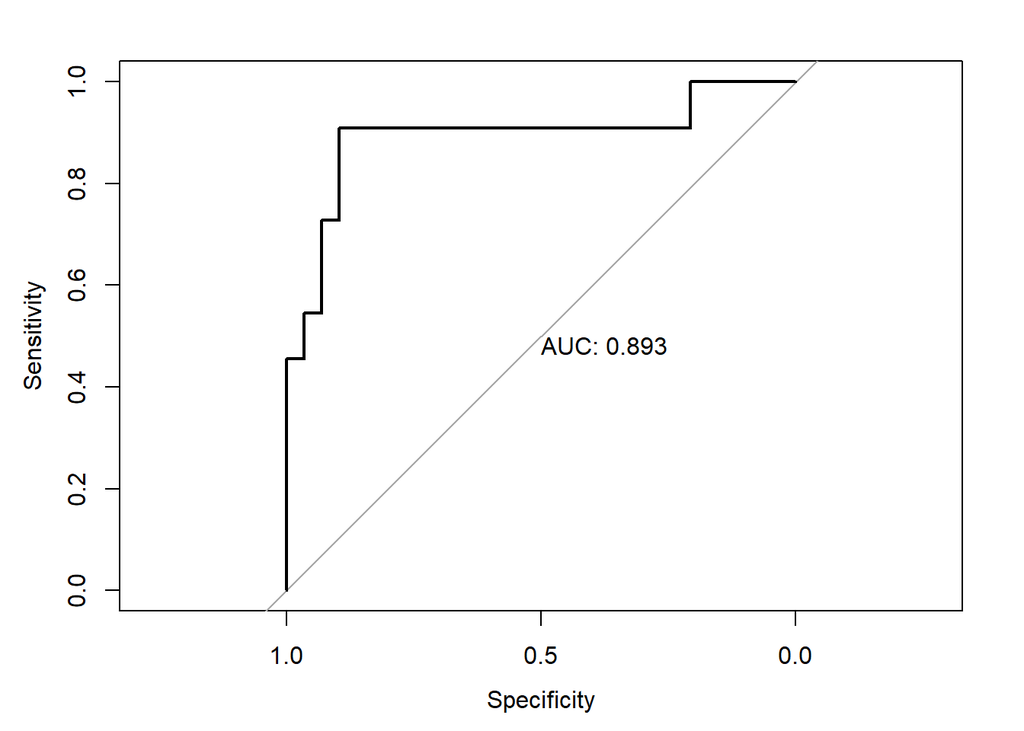

```r
patients_A_full_log_reg <- glm(CONTROLADO ~ ROTA_CERV_DER +
                               ROTA_CERV_IZQ +
                               FLEX_FRONT_CERV_FLEXION +
                               FLEX_FRONT_CERV_EXTENSION +
                               FLEX_LAT_CERV_DERECHA +
                               FLEX_LAT_CERV_IZQUIERDA +
                               FLEX_LUMBAR_LAT_IZQUIERDA,
                             data = datos, family = "binomial")

get_roc_curve(patients_A_full_log_reg)
```

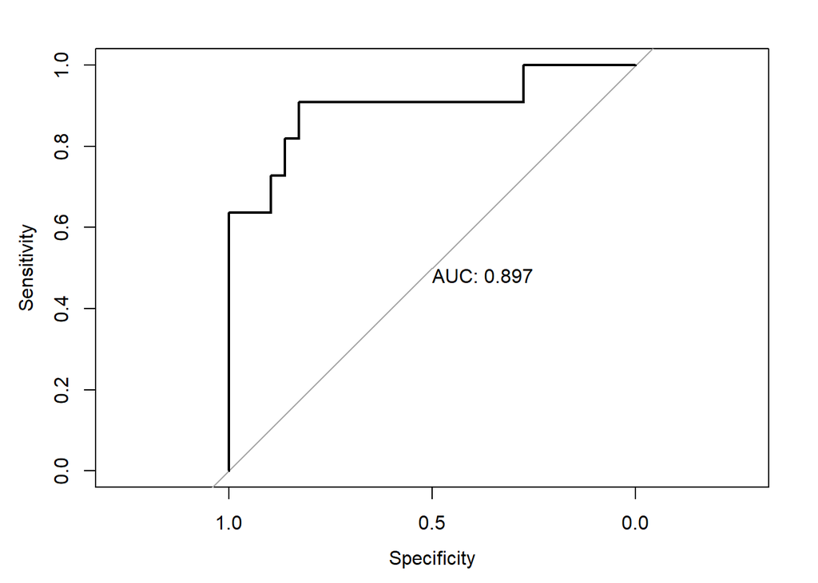

```r
patients_B_full_log_reg <- glm(CONTROLADO ~ ROTA_CERV_DER +
                               ROTA_CERV_IZQ +
                               FLEX_FRONT_CERV_FLEXION +
                               FLEX_FRONT_CERV_EXTENSION +
                               FLEX_LAT_CERV_DERECHA +
                               FLEX_LAT_CERV_IZQUIERDA +
                               FLEX_LUMBAR_LAT_IZQUIERDA +
                               DISTANCIA_INTERMALEOLAR,
                             data = datos, family = "binomial")

get_roc_curve(patients_B_full_log_reg)
```

```r
patients_B_full_log_reg_pred <- predict(patients_B_full_log_reg, datos,
                                        type = 'response')

patients_B_full_log_reg_pred <- as_factor(if_else(patients_B_full_log_reg_pred < 0.5,
                                                  'SI', 'NO'))

confusionMatrix(patients_B_full_log_reg_pred, datos$CONTROLADO)
```

```
## Confusion Matrix and Statistics
##
##           Reference
## Prediction SI NO
##         SI 28  4
##         NO  1  7
##
##                Accuracy : 0.875
##                  95% CI : (0.732, 0.9581)
##     No Information Rate : 0.725
##     P-Value [Acc > NIR] : 0.02002
##
##                   Kappa : 0.6575
##
##  Mcnemar's Test P-Value : 0.37109
##
##             Sensitivity : 0.9655
##             Specificity : 0.6364
##          Pos Pred Value : 0.8750
##          Neg Pred Value : 0.8750
##              Prevalence : 0.7250
##          Detection Rate : 0.7000
##    Detection Prevalence : 0.8000
##       Balanced Accuracy : 0.8009
##
##        'Positive' Class : SI
##
```

## 3.2 Logistic Bayesian Regression

Bayesian regression (Bürkner 2017):

### 3.2.1 Prior distributions

- `PESO_kg`:

```r
shapiro.test(datos$PESO_kg)
```

```
##
##  Shapiro-Wilk normality test
##
## data:  datos$PESO_kg
## W = 0.9838, p-value = 0.826
```

The data comes from a normal distribution.

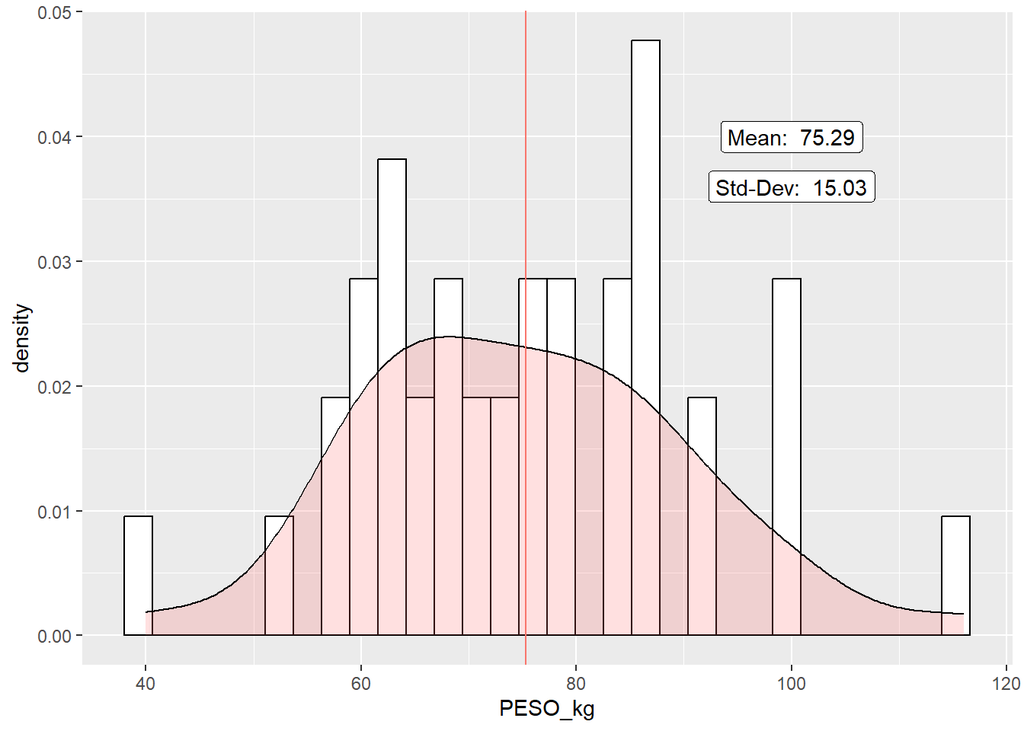

```r
datos %>%
  ggplot(aes(x = PESO_kg)) +
  geom_histogram(aes(y=..density..), colour="black", fill="white")+
  geom_density(alpha=.2, fill="#FF6666") +
  #stat_density(alpha = 0.5) +
  geom_vline(aes(xintercept = mean(PESO_kg), colour = 'mean mass')) +
  geom_label(x = 100, y = 0.04, aes(label = paste('Mean: ', round(mean(PESO_kg),2)))) +
  geom_label(x = 100, y = 0.036, aes(label = paste('Std-Dev: ', round(sd(PESO_kg),2)))) +
  theme(legend.position = 'none')
```

- `ROTA_CERV_IZQ`:

```r
shapiro.test(datos$ROTA_CERV_IZQ)
```

```
##
##  Shapiro-Wilk normality test
##
## data:  datos$ROTA_CERV_IZQ
## W = 0.94943, p-value = 0.0725
```

The data comes from a normal distribution.

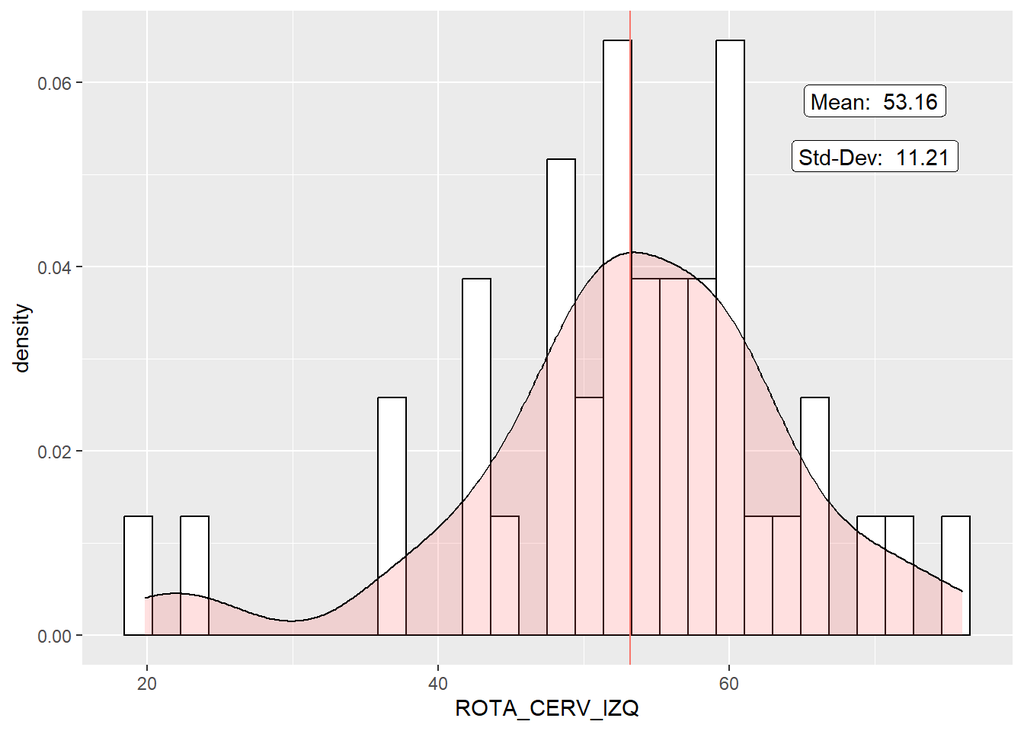

```r
datos %>%
  ggplot(aes(x = ROTA_CERV_IZQ)) +
  geom_histogram(aes(y=..density..), colour="black", fill="white")+
  geom_density(alpha=.2, fill="#FF6666") +
  #stat_density(alpha = 0.5) +
  geom_vline(aes(xintercept = mean(ROTA_CERV_IZQ), colour = 'ROTA_CERV_IZQ')) +
  geom_label(x = 70, y = 0.058, aes(label = paste('Mean: ', round(mean(ROTA_CERV_IZQ),2)))) +
  geom_label(x = 70, y = 0.052, aes(label = paste('Std-Dev: ', round(sd(ROTA_CERV_IZQ),2)))) +
  theme(legend.position = 'none')
```

- `ROTA_CERV_DER`:

```r
shapiro.test(datos$ROTA_CERV_DER)
```

```
##
##  Shapiro-Wilk normality test
##
## data:  datos$ROTA_CERV_DER
## W = 0.96475, p-value = 0.2425
```

The data comes from a normal distribution.

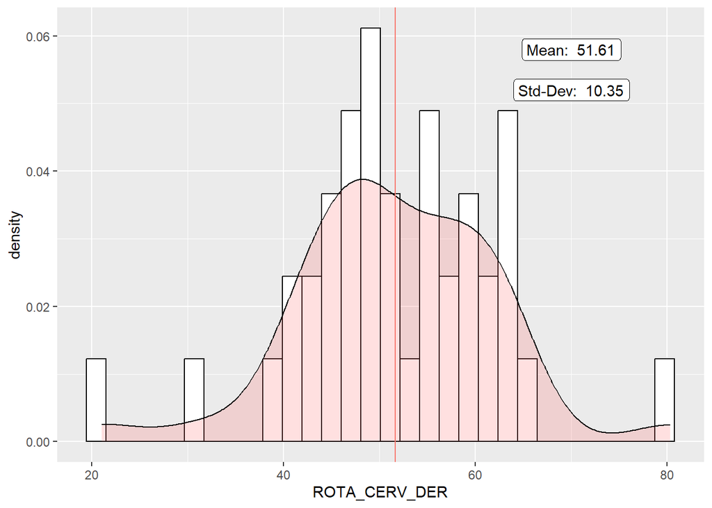

```r
datos %>%
  ggplot(aes(x = ROTA_CERV_DER)) +
  geom_histogram(aes(y=..density..), colour="black", fill="white")+
  geom_density(alpha=.2, fill="#FF6666") +
  #stat_density(alpha = 0.5) +
  geom_vline(aes(xintercept = mean(ROTA_CERV_DER), colour = 'ROTA_CERV_IZQ')) +
  geom_label(x = 70, y = 0.058, aes(label = paste('Mean: ', round(mean(ROTA_CERV_DER),2)))) +
  geom_label(x = 70, y = 0.052, aes(label = paste('Std-Dev: ', round(sd(ROTA_CERV_DER),2)))) +
  theme(legend.position = 'none')
```

- `SCHOBERT_MOD`

Then,

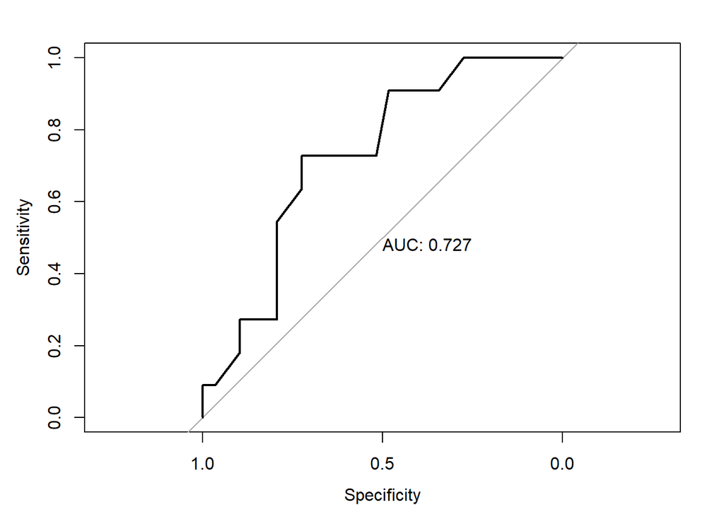

```r
SCHOBERT_MOD_STAN <- datos %>%
  select(SCHOBERT_MOD) %>%
  mutate(SCHOBERT_MOD_STAN = (SCHOBERT_MOD - mean(SCHOBERT_MOD))/sd(SCHOBERT_MOD)) %>%
  pull(SCHOBERT_MOD_STAN)


SCHOBERT_MOD_log_reg <- glm(CONTROLADO ~ SCHOBERT_MOD_STAN,
                            data = datos, family = "binomial")

get_roc_curve(SCHOBERT_MOD_log_reg)
```

```r
summary(SCHOBERT_MOD_log_reg)
```

```
##
## Call:
## glm(formula = CONTROLADO ~ SCHOBERT_MOD_STAN, family = "binomial",
##     data = datos)
##
## Deviance Residuals:
##     Min       1Q   Median       3Q      Max
## -1.3263  -0.7407  -0.5600   0.8874   1.9647
##
## Coefficients:
##                   Estimate Std. Error z value Pr(>|z|)
## (Intercept)        -1.1322     0.4052  -2.794  0.00521 **
## SCHOBERT_MOD_STAN  -0.9116     0.4283  -2.128  0.03332 *
## ---
## Signif. codes:  0 '***' 0.001 '**' 0.01 '*' 0.05 '.' 0.1 ' ' 1
##
## (Dispersion parameter for binomial family taken to be 1)
##
##     Null deviance: 47.054  on 39  degrees of freedom
## Residual deviance: 41.627  on 38  degrees of freedom
## AIC: 45.627
##
## Number of Fisher Scoring iterations: 4
```

Prior distributions:

```r
priors_SCHOBERT <- c(prior('normal(0, 1.1322)', class = 'Intercept'),
                     prior('normal(0, 0.9116)', class = 'b', coef = 'SCHOBERT_MOD_STAN'))
```

Then,

```r
data_SCHOBERT <- data.frame(
  'CONTROLADO' = if_else(datos$CONTROLADO == 'SI', 0, 1),
  'SCHOBERT_MOD_STAN' = SCHOBERT_MOD_STAN
)

SCHOBERT_MOD_BAYESIAN <- brm(CONTROLADO ~ 1 + SCHOBERT_MOD_STAN,
                             data = data_SCHOBERT,
                             family = 'binomial',
                             cores = 4,
                             prior = priors_SCHOBERT)
```

```
## Using the maximum response value as the number of trials.
```

```
## Only 2 levels detected so that family 'bernoulli' might be a more efficient choice.
```

```r
summary(SCHOBERT_MOD_BAYESIAN)
```

```
##  Family: binomial
##   Links: mu = logit
## Formula: CONTROLADO ~ 1 + SCHOBERT_MOD_STAN
##    Data: data_SCHOBERT (Number of observations: 40)
##   Draws: 4 chains, each with iter = 2000; warmup = 1000; thin = 1;
##          total post-warmup draws = 4000
##
## Population-Level Effects:
##                   Estimate Est.Error l-95% CI u-95% CI Rhat Bulk_ESS Tail_ESS
## Intercept            -1.01      0.36    -1.77    -0.34 1.00     2419     2057
## SCHOBERT_MOD_STAN    -0.77      0.37    -1.53    -0.10 1.00     2660     2065
##
## Draws were sampled using sampling(NUTS). For each parameter, Bulk_ESS
## and Tail_ESS are effective sample size measures, and Rhat is the potential
## scale reduction factor on split chains (at convergence, Rhat = 1).
```

Plots:

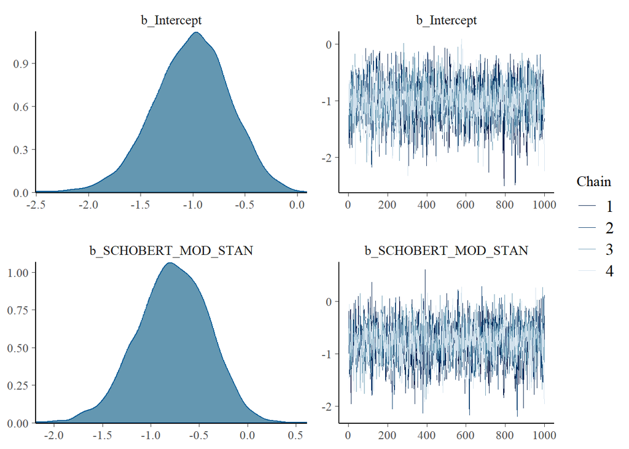

```r
plot(SCHOBERT_MOD_BAYESIAN)
```

- Prior:

```r
describe_prior(SCHOBERT_MOD_BAYESIAN)
```

```
##             Parameter Prior_Distribution Prior_Location Prior_Scale Prior_df
## 1         b_Intercept             normal              0      1.1322       NA
## 2 b_SCHOBERT_MOD_STAN             normal              0      0.9116       NA
```

- Posterior:

```r
describe_posterior(SCHOBERT_MOD_BAYESIAN)
```

```
## Summary of Posterior Distribution
##
## Parameter         | Median |         95% CI |     pd |          ROPE | % in ROPE |  Rhat |     ESS
## --------------------------------------------------------------------------------------------------
## (Intercept)       |  -0.99 | [-1.77, -0.34] | 99.95% | [-0.18, 0.18] |        0% | 1.002 | 2295.00
## SCHOBERT_MOD_STAN |  -0.77 | [-1.53, -0.10] | 98.70% | [-0.18, 0.18] |     2.24% | 1.001 | 2594.00
```

Predictions:

```r
SCHOBERT_MOD_BAYESIAN_pred <- predict(SCHOBERT_MOD_BAYESIAN, data_SCHOBERT)
```

```
## Using the maximum response value as the number of trials.
```

```
## Using the maximum response value as the number of trials.
```

```r
SCHOBERT_MOD_BAYESIAN_pred1 <- as_factor(if_else(SCHOBERT_MOD_BAYESIAN_pred[,1] < 0.5,
                                                  'SI', 'NO'))

confusionMatrix(SCHOBERT_MOD_BAYESIAN_pred1, datos$CONTROLADO)
```

```
## Confusion Matrix and Statistics
##
##           Reference
## Prediction SI NO
##         SI 27  8
##         NO  2  3
##
##                Accuracy : 0.75
##                  95% CI : (0.588, 0.8731)
##     No Information Rate : 0.725
##     P-Value [Acc > NIR] : 0.4402
##
##                   Kappa : 0.2453
##
##  Mcnemar's Test P-Value : 0.1138
##
##             Sensitivity : 0.9310
##             Specificity : 0.2727
##          Pos Pred Value : 0.7714
##          Neg Pred Value : 0.6000
##              Prevalence : 0.7250
##          Detection Rate : 0.6750
##    Detection Prevalence : 0.8750
##       Balanced Accuracy : 0.6019
##
##        'Positive' Class : SI
##
```

- `FLEX_FRONT_CERV_FLEXION`:

```r
shapiro.test(datos$FLEX_FRONT_CERV_FLEXION)
```

```
##
##  Shapiro-Wilk normality test
##
## data:  datos$FLEX_FRONT_CERV_FLEXION
## W = 0.98144, p-value = 0.7427
```

The data comes from a normal distribution.

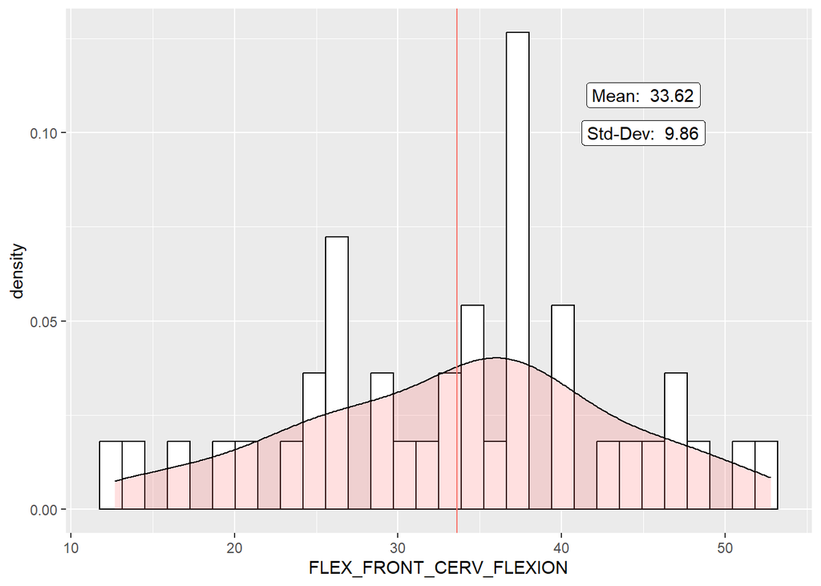

```r
datos %>%
  ggplot(aes(x = FLEX_FRONT_CERV_FLEXION)) +
  geom_histogram(aes(y=..density..), colour="black", fill="white")+
  geom_density(alpha=.2, fill="#FF6666") +
  #stat_density(alpha = 0.5) +
  geom_vline(aes(xintercept = mean(FLEX_FRONT_CERV_FLEXION), colour = 'ROTA_CERV_IZQ')) +
  geom_label(x = 45, y = 0.11, aes(label = paste('Mean: ', round(mean(FLEX_FRONT_CERV_FLEXION),2)))) +
  geom_label(x = 45, y = 0.10, aes(label = paste('Std-Dev: ', round(sd(FLEX_FRONT_CERV_FLEXION),2)))) +
  theme(legend.position = 'none')
```

- `FLEX_FRONT_CERV_EXTENSION`:

```r
shapiro.test(datos$FLEX_FRONT_CERV_EXTENSION)
```

```
##
##  Shapiro-Wilk normality test
##
## data:  datos$FLEX_FRONT_CERV_EXTENSION
## W = 0.97251, p-value = 0.4306
```

The data comes from a normal distribution.

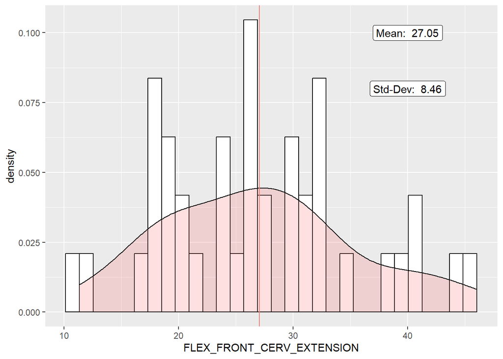

```r
datos %>%
  ggplot(aes(x = FLEX_FRONT_CERV_EXTENSION)) +
  geom_histogram(aes(y=..density..), colour="black", fill="white")+
  geom_density(alpha=.2, fill="#FF6666") +
  #stat_density(alpha = 0.5) +
  geom_vline(aes(xintercept = mean(FLEX_FRONT_CERV_EXTENSION, na.rm = T),
                 colour = 'FLEX_FRONT_CERV_EXTENSION')) +
  geom_label(x = 40, y = 0.10, aes(label = paste('Mean: ', round(mean(FLEX_FRONT_CERV_EXTENSION,
                                                                      na.rm = T),2)))) +
  geom_label(x = 40, y = 0.08, aes(label = paste('Std-Dev: ', round(sd(FLEX_FRONT_CERV_EXTENSION,
                                                                       na.rm = T),2)))) +
  theme(legend.position = 'none')
```

Hyper-parameters:

```r
summary(datos)
```

```
##     PESO_kg       ROTA_CERV_IZQ   ROTA_CERV_DER   FLEX_FRONT_CERV_FLEXION
##  Min.   : 40.00   Min.   :19.80   Min.   :21.00   Min.   :12.70
##  1st Qu.: 63.77   1st Qu.:48.55   1st Qu.:46.10   1st Qu.:26.60
##  Median : 74.50   Median :53.60   Median :50.70   Median :35.05
##  Mean   : 75.29   Mean   :53.16   Mean   :51.61   Mean   :33.62
##  3rd Qu.: 86.05   3rd Qu.:60.08   3rd Qu.:58.75   3rd Qu.:39.62
##  Max.   :116.00   Max.   :76.00   Max.   :80.30   Max.   :52.80
##  FLEX_FRONT_CERV_EXTENSION FLEX_LAT_CERV_DERECHA FLEX_LAT_CERV_IZQUIERDA
##  Min.   :11.33             Min.   :13.80         Min.   :14.60
##  1st Qu.:20.50             1st Qu.:22.98         1st Qu.:21.15
##  Median :26.50             Median :30.65         Median :28.70
##  Mean   :27.05             Mean   :29.72         Mean   :28.82
##  3rd Qu.:31.82             3rd Qu.:36.42         3rd Qu.:35.23
##  Max.   :46.00             Max.   :45.80         Max.   :41.90
##   SCHOBERT_MOD   FLEX_LUMBAR_LAT_DERECHA FLEX_LUMBAR_LAT_IZQUIERDA
##  Min.   :13.00   Min.   : 6.40           Min.   : 6.40
##  1st Qu.:18.00   1st Qu.:12.75           1st Qu.:12.28
##  Median :20.00   Median :15.75           Median :16.50
##  Mean   :19.88   Mean   :15.24           Mean   :15.51
##  3rd Qu.:22.00   3rd Qu.:18.77           3rd Qu.:19.00
##  Max.   :26.00   Max.   :22.50           Max.   :24.60
##  DISTANCIA_INTERMALEOLAR CONTROLADO
##  Min.   :20.00           SI:29
##  1st Qu.:26.75           NO:11
##  Median :32.00
##  Mean   :31.66
##  3rd Qu.:36.25
##  Max.   :46.00
```

Then,

```r
full_bayesian_model_log_reg <- brm(CONTROLADO ~ .,
                                   data = datos,
                                   family = bernoulli(link = "logit"),
                                   chains = 4,
                                   cores = 4,
                                   seed = 17)
summary(full_bayesian_model_log_reg)
```

```
##  Family: bernoulli
##   Links: mu = logit
## Formula: CONTROLADO ~ PESO_kg + ROTA_CERV_IZQ + ROTA_CERV_DER + FLEX_FRONT_CERV_FLEXION + FLEX_FRONT_CERV_EXTENSION + FLEX_LAT_CERV_DERECHA + FLEX_LAT_CERV_IZQUIERDA + SCHOBERT_MOD + FLEX_LUMBAR_LAT_DERECHA + FLEX_LUMBAR_LAT_IZQUIERDA + DISTANCIA_INTERMALEOLAR
##    Data: datos (Number of observations: 40)
##   Draws: 4 chains, each with iter = 2000; warmup = 1000; thin = 1;
##          total post-warmup draws = 4000
##
## Population-Level Effects:
##                           Estimate Est.Error l-95% CI u-95% CI Rhat Bulk_ESS
## Intercept                    61.69     24.61    22.39   116.29 1.00      784
## PESO_kg                      -0.20      0.09    -0.38    -0.05 1.00      982
## ROTA_CERV_IZQ                 0.12      0.15    -0.15     0.44 1.01     1361
## ROTA_CERV_DER                -0.24      0.16    -0.57     0.03 1.01     1437
## FLEX_FRONT_CERV_FLEXION      -0.72      0.28    -1.36    -0.26 1.00      957
## FLEX_FRONT_CERV_EXTENSION     0.22      0.19    -0.14     0.62 1.00     1348
## FLEX_LAT_CERV_DERECHA        -0.24      0.37    -1.04     0.41 1.00     1086
## FLEX_LAT_CERV_IZQUIERDA       0.55      0.40    -0.16     1.43 1.00     1015
## SCHOBERT_MOD                 -0.80      0.55    -2.04     0.13 1.00     1091
## FLEX_LUMBAR_LAT_DERECHA      -1.30      0.87    -3.30     0.18 1.00     1048
## FLEX_LUMBAR_LAT_IZQUIERDA     0.93      0.76    -0.45     2.58 1.00     1132
## DISTANCIA_INTERMALEOLAR      -0.45      0.24    -0.97    -0.06 1.00     1038
##                           Tail_ESS
## Intercept                     1365
## PESO_kg                       1352
## ROTA_CERV_IZQ                 1373
## ROTA_CERV_DER                 1437
## FLEX_FRONT_CERV_FLEXION       1378
## FLEX_FRONT_CERV_EXTENSION     1589
## FLEX_LAT_CERV_DERECHA         1666
## FLEX_LAT_CERV_IZQUIERDA       1475
## SCHOBERT_MOD                  1638
## FLEX_LUMBAR_LAT_DERECHA       1221
## FLEX_LUMBAR_LAT_IZQUIERDA     1474
## DISTANCIA_INTERMALEOLAR       1463
##
## Draws were sampled using sampling(NUTS). For each parameter, Bulk_ESS
## and Tail_ESS are effective sample size measures, and Rhat is the potential
## scale reduction factor on split chains (at convergence, Rhat = 1).
```

```
## No divergences to plot.
```

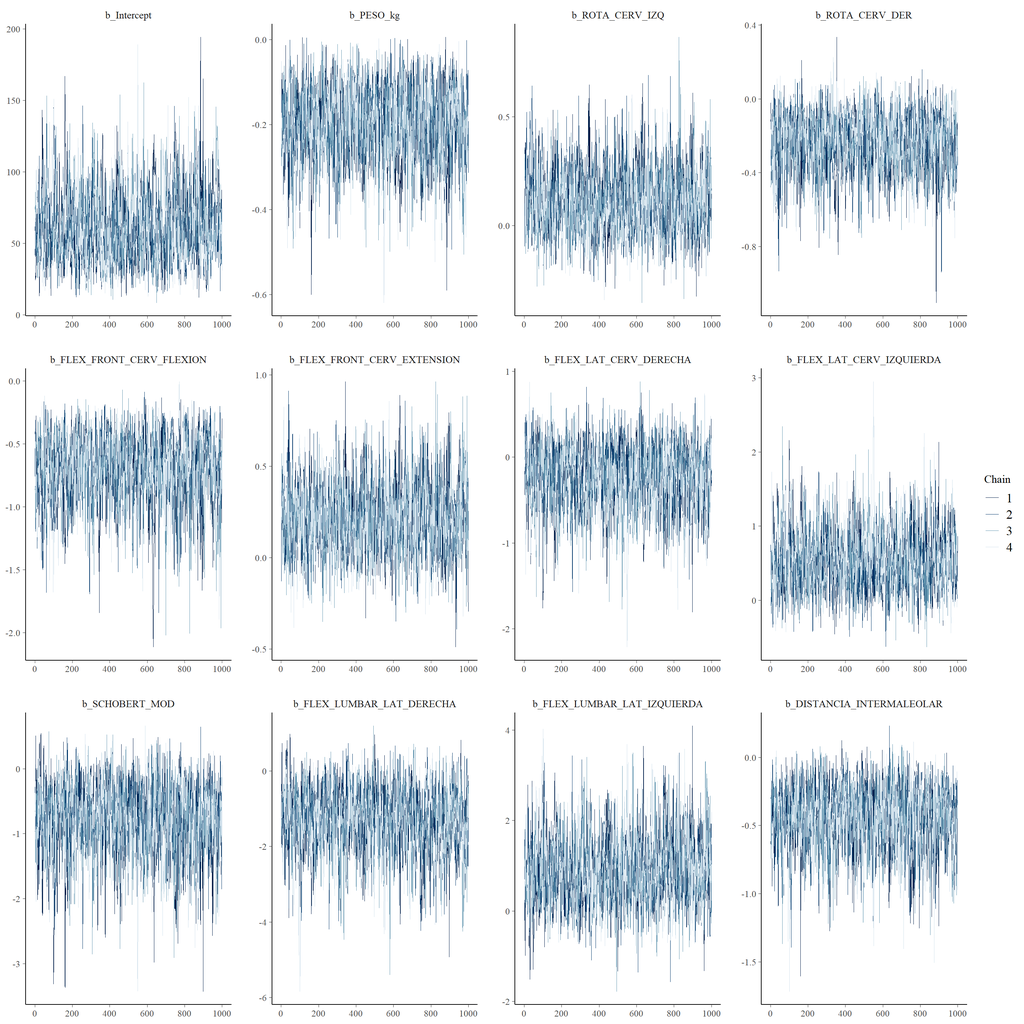

```r
stanplot(full_bayesian_model_log_reg,
         type = "trace")
```

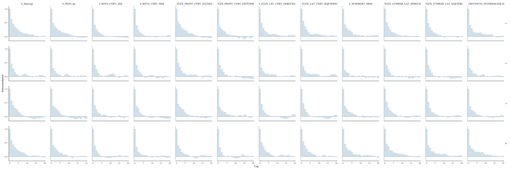

```r
stanplot(full_bayesian_model_log_reg,
         type = "acf_bar")
```

```r
post <- posterior_samples(full_bayesian_model_log_reg)
full_bayesian_model_log_reg_pred <- predict(full_bayesian_model_log_reg, datos, re_formula = NA)

datos <- cbind(datos, full_bayesian_model_log_reg_pred)

datos <- datos %>%
  mutate(full_log_reg_bayesian_predictions = as_factor(if_else(Estimate < 0.5, 'SI', 'NO')))

confusionMatrix(datos$CONTROLADO, datos$full_log_reg_bayesian_predictions)
```

```
## Confusion Matrix and Statistics
##
##           Reference
## Prediction SI NO
##         SI 27  2
##         NO  3  8
##
##                Accuracy : 0.875
##                  95% CI : (0.732, 0.9581)
##     No Information Rate : 0.75
##     P-Value [Acc > NIR] : 0.04327
##
##                   Kappa : 0.6774
##
##  Mcnemar's Test P-Value : 1.00000
##
##             Sensitivity : 0.9000
##             Specificity : 0.8000
##          Pos Pred Value : 0.9310
##          Neg Pred Value : 0.7273
##              Prevalence : 0.7500
##          Detection Rate : 0.6750
##    Detection Prevalence : 0.7250
##       Balanced Accuracy : 0.8500
##
##        'Positive' Class : SI
##
```

Then,

```r
#get_roc_curve(full_bayesian_model_log_reg)
```

# References

Bürkner, Paul-Christian. 2017. “Brms: An r Package for Bayesian Multilevel Models Using Stan.” *Journal of Statistical Software* 80: 1–28.